# Credit Chronicles: Exploring Cardholder Behavior

##### **Authors**: Tulasi Thotakura, Sai Krishna Paila, Gourab Mukherjee

##### **Keywords-** Credit Card, Exploratory data analysis, Utilization Ratio

## Abstract

In the “Credit Chronicles: Exploring Cardholder Behavior” project, our team, is dedicated to investigate the interactions between 10,127 clients and a financial institution. The data set at our disposal encompasses a wide array of client attributes, including age, income category, and credit card preferences. We aim to discern distinct customer segments through the process of customer segmentation, seeking to understand how these attributes combine to define unique client groups. Our research is also focused on the analysis of transaction patterns and behaviors across various income categories, which enables us to gain valuable insights into typical client practices. Furthermore, we delve into the intricate relationship between a client’s average utilization ratio and their credit limit, with a particular emphasis on encouraging responsible credit utilization. One of the central objectives of our project is to pinpoint the primary drivers of client attrition. Our aim is to categorize these factors based on elements such as age, credit utilization, or contact frequency. In addition, we explore the correlation between client income categories and attrition rates, with the ultimate goal of devising strategies to retain clients in lower income brackets. The “Credit Chronicles” data set, hosted on our GitHub repository, serves as an invaluable resource for this research, providing a robust foundation for an in-depth exploration of client profiles and behaviors. The findings we uncover are anticipated to provide insights that can significantly enhance the overall banking experience, and we believe they will prove to be instrumental for financial institutions in their mission to better serve their clients.

## Introduction

In the era of evolving financial services and dynamic customer expectations, the “Credit Chronicles” project stands at the forefront of analyzing and optimizing the client experience. With a dataset encompassing over 10,000 individuals and their interactions with a financial institution, the project unveils a treasure trove of insights into clients’ behavior and preferences. This comprehensive dataset provides a rich tapestry of demographic information, including age, gender, education level, marital status, and income category. Moreover, it delves deep into credit card usage patterns, revealing details about credit limits, transaction behaviors, and card categories. The dataset doesn’t stop at the surface level; it also delves into the dynamics of banking relationships, shedding light on the total number of relationships and months of inactivity. This wealth of data offers an exceptional opportunity to unravel the mysteries of client profiles and behaviors, serving as a foundation for a holistic analysis of factors influencing banking relationships, credit card usage patterns, and, significantly, client attrition. The project aspires to understand the nuanced intricacies of client segments, transaction behaviors across diverse income categories, the correlation between credit utilization and credit limits, the factors underpinning client attrition, and strategies to retain clients, particularly those in lower income categories.

As the project unfolds, the team’s data preprocessing efforts have been meticulous, including data loading, type validation, and the management of null values. Further statistical analyses, such as t-tests, chi-squared tests, and correlation assessments, have revealed invaluable insights, uncovering distinctions and relationships that hold the potential to reshape the financial landscape. “Credit Chronicles” is poised to answer critical questions and provide actionable recommendations to enhance the overall banking experience. By harnessing the power of data and the art of statistical analysis, this project seeks to revolutionize banking, offering clients personalized services and ensuring that financial institutions remain at the forefront of an ever-evolving industry.

## Data and methodology

The “Credit Chronicles” project is built upon a dataset acquired from Kaggle, which offers insights into the financial behaviors of 10,127 clients and their interactions with a financial institution. This dataset includes a range of client attributes, spanning age, gender, education level, marital status, and income categories. Additionally, it delves into credit card usage patterns, encompassing credit limits, transaction amounts, and card categories, while also shedding light on banking relationships, such as the total number of relationships and periods of inactivity.

To ensure data readiness, the team has diligently conducted data preprocessing tasks, which encompass the verification of data types, handling of null values, and the structuring of data for subsequent analysis. In the methodological approach, a suite of statistical techniques, such as t-tests, chi-squared tests, and correlation analyses, are applied to uncover hidden patterns, correlations, and distinctions within the dataset. With research objectives centered around customer segmentation, transaction behaviors in different income categories, the factors contributing to client attrition, credit utilization patterns, and the relationship between income categories and client churn, this project aims to provide actionable insights that can inform strategic decisions and enhance the overall banking experience.

#### Summary Statistics

```
## 'data.frame':    10127 obs. of  23 variables:
##  $ CLIENTNUM                                                                                                                         : int  768805383 818770008 713982108 769911858 709106358 713061558 810347208 818906208 710930508 719661558 ...
##  $ Attrition_Flag                                                                                                                    : chr  "Existing Customer" "Existing Customer" "Existing Customer" "Existing Customer" ...
##  $ Customer_Age                                                                                                                      : int  45 49 51 40 40 44 51 32 37 48 ...
##  $ Gender                                                                                                                            : chr  "M" "F" "M" "F" ...
##  $ Dependent_count                                                                                                                   : int  3 5 3 4 3 2 4 0 3 2 ...
##  $ Education_Level                                                                                                                   : chr  "High School" "Graduate" "Graduate" "High School" ...
##  $ Marital_Status                                                                                                                    : chr  "Married" "Single" "Married" "Unknown" ...
##  $ Income_Category                                                                                                                   : chr  "$60K - $80K" "Less than $40K" "$80K - $120K" "Less than $40K" ...
##  $ Card_Category                                                                                                                     : chr  "Blue" "Blue" "Blue" "Blue" ...
##  $ Months_on_book                                                                                                                    : int  39 44 36 34 21 36 46 27 36 36 ...
##  $ Total_Relationship_Count                                                                                                          : int  5 6 4 3 5 3 6 2 5 6 ...
##  $ Months_Inactive_12_mon                                                                                                            : int  1 1 1 4 1 1 1 2 2 3 ...
##  $ Contacts_Count_12_mon                                                                                                             : int  3 2 0 1 0 2 3 2 0 3 ...
##  $ Credit_Limit                                                                                                                      : num  12691 8256 3418 3313 4716 ...
##  $ Total_Revolving_Bal                                                                                                               : int  777 864 0 2517 0 1247 2264 1396 2517 1677 ...
##  $ Avg_Open_To_Buy                                                                                                                   : num  11914 7392 3418 796 4716 ...
##  $ Total_Amt_Chng_Q4_Q1                                                                                                              : num  1.33 1.54 2.59 1.4 2.17 ...
##  $ Total_Trans_Amt                                                                                                                   : int  1144 1291 1887 1171 816 1088 1330 1538 1350 1441 ...
##  $ Total_Trans_Ct                                                                                                                    : int  42 33 20 20 28 24 31 36 24 32 ...
##  $ Total_Ct_Chng_Q4_Q1                                                                                                               : num  1.62 3.71 2.33 2.33 2.5 ...
##  $ Avg_Utilization_Ratio                                                                                                             : num  0.061 0.105 0 0.76 0 0.311 0.066 0.048 0.113 0.144 ...
##  $ Naive_Bayes_Classifier_Attrition_Flag_Card_Category_Contacts_Count_12_mon_Dependent_count_Education_Level_Months_Inactive_12_mon_1: num  9.34e-05 5.69e-05 2.11e-05 1.34e-04 2.17e-05 ...
##  $ Naive_Bayes_Classifier_Attrition_Flag_Card_Category_Contacts_Count_12_mon_Dependent_count_Education_Level_Months_Inactive_12_mon_2: num  1 1 1 1 1 ...
## NULL
```

```
##    CLIENTNUM         Attrition_Flag      Customer_Age      Gender
##  Min.   :708082083   Length:10127       Min.   :26.00   Length:10127
##  1st Qu.:713036770   Class :character   1st Qu.:41.00   Class :character
##  Median :717926358   Mode  :character   Median :46.00   Mode  :character
##  Mean   :739177606                      Mean   :46.33
##  3rd Qu.:773143533                      3rd Qu.:52.00
##  Max.   :828343083                      Max.   :73.00
##  Dependent_count Education_Level    Marital_Status     Income_Category
##  Min.   :0.000   Length:10127       Length:10127       Length:10127
##  1st Qu.:1.000   Class :character   Class :character   Class :character
##  Median :2.000   Mode  :character   Mode  :character   Mode  :character
##  Mean   :2.346
##  3rd Qu.:3.000
##  Max.   :5.000
##  Card_Category      Months_on_book  Total_Relationship_Count
##  Length:10127       Min.   :13.00   Min.   :1.000
##  Class :character   1st Qu.:31.00   1st Qu.:3.000
##  Mode  :character   Median :36.00   Median :4.000
##                     Mean   :35.93   Mean   :3.813
##                     3rd Qu.:40.00   3rd Qu.:5.000
##                     Max.   :56.00   Max.   :6.000
##  Months_Inactive_12_mon Contacts_Count_12_mon  Credit_Limit
##  Min.   :0.000          Min.   :0.000         Min.   : 1438
##  1st Qu.:2.000          1st Qu.:2.000         1st Qu.: 2555
##  Median :2.000          Median :2.000         Median : 4549
##  Mean   :2.341          Mean   :2.455         Mean   : 8632
##  3rd Qu.:3.000          3rd Qu.:3.000         3rd Qu.:11068
##  Max.   :6.000          Max.   :6.000         Max.   :34516
##  Total_Revolving_Bal Avg_Open_To_Buy Total_Amt_Chng_Q4_Q1 Total_Trans_Amt
##  Min.   :   0        Min.   :    3   Min.   :0.0000       Min.   :  510
##  1st Qu.: 359        1st Qu.: 1324   1st Qu.:0.6310       1st Qu.: 2156
##  Median :1276        Median : 3474   Median :0.7360       Median : 3899
##  Mean   :1163        Mean   : 7469   Mean   :0.7599       Mean   : 4404
##  3rd Qu.:1784        3rd Qu.: 9859   3rd Qu.:0.8590       3rd Qu.: 4741
##  Max.   :2517        Max.   :34516   Max.   :3.3970       Max.   :18484
##  Total_Trans_Ct   Total_Ct_Chng_Q4_Q1 Avg_Utilization_Ratio
##  Min.   : 10.00   Min.   :0.0000      Min.   :0.0000
##  1st Qu.: 45.00   1st Qu.:0.5820      1st Qu.:0.0230
##  Median : 67.00   Median :0.7020      Median :0.1760
##  Mean   : 64.86   Mean   :0.7122      Mean   :0.2749
##  3rd Qu.: 81.00   3rd Qu.:0.8180      3rd Qu.:0.5030
##  Max.   :139.00   Max.   :3.7140      Max.   :0.9990
##  Naive_Bayes_Classifier_Attrition_Flag_Card_Category_Contacts_Count_12_mon_Dependent_count_Education_Level_Months_Inactive_12_mon_1
##  Min.   :0.0000077
##  1st Qu.:0.0000990
##  Median :0.0001815
##  Mean   :0.1599975
##  3rd Qu.:0.0003373
##  Max.   :0.9995800
##  Naive_Bayes_Classifier_Attrition_Flag_Card_Category_Contacts_Count_12_mon_Dependent_count_Education_Level_Months_Inactive_12_mon_2
##  Min.   :0.00042
##  1st Qu.:0.99966
##  Median :0.99982
##  Mean   :0.84000
##  3rd Qu.:0.99990
##  Max.   :0.99999
```

## EDA of Categorical Variables

In the “Data Distribution” section, we leverage the ggplot2 library to visualize the distribution of categorical variables within the data set. These visualizations are essential for gaining insights into how different attributes, such as “Attrition_Flag,” “Gender,” “Education_Level,” “Marital_Status,” “Income_Category,” and “Card_Category,” are distributed and contribute to the overall data set. The bar graphs provide a clear depiction of the count of each category within these attributes. This analysis helps uncover patterns, frequencies, and variations, which are vital for understanding customer segments and their behavior in the context of credit card usage.

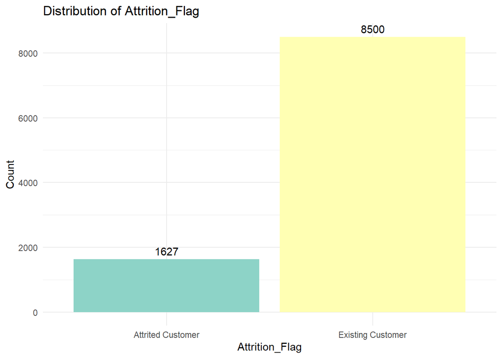

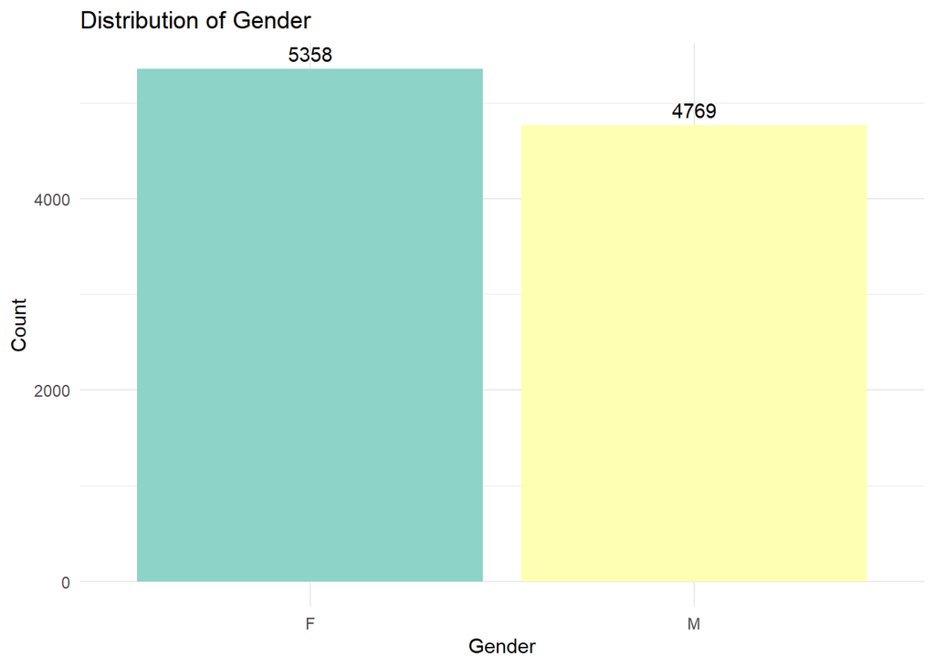

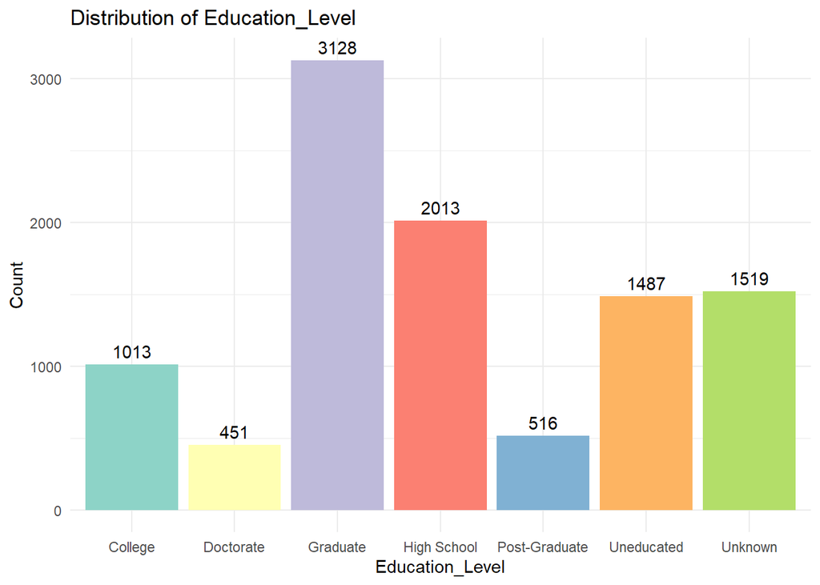

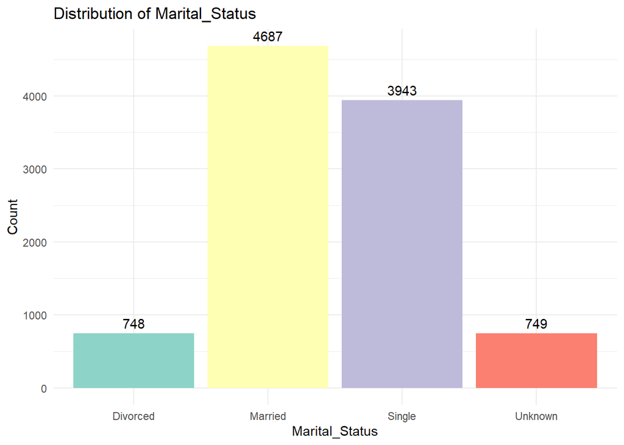

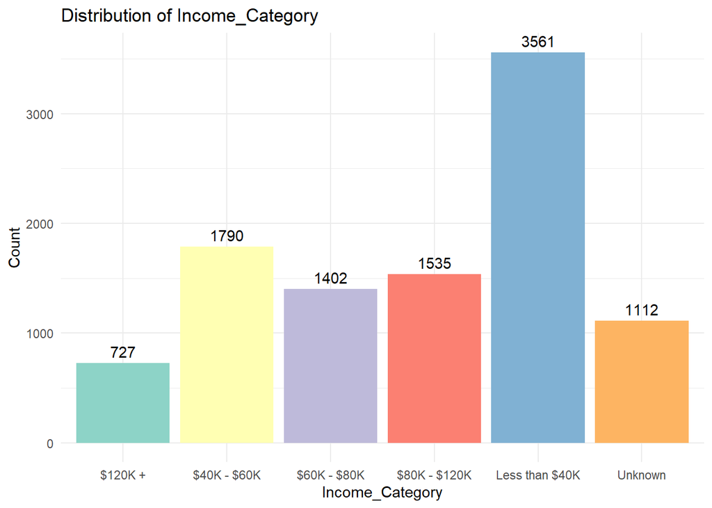

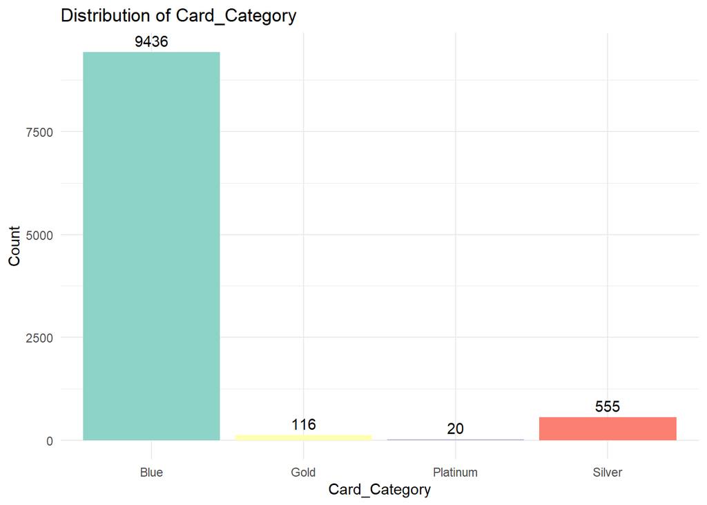

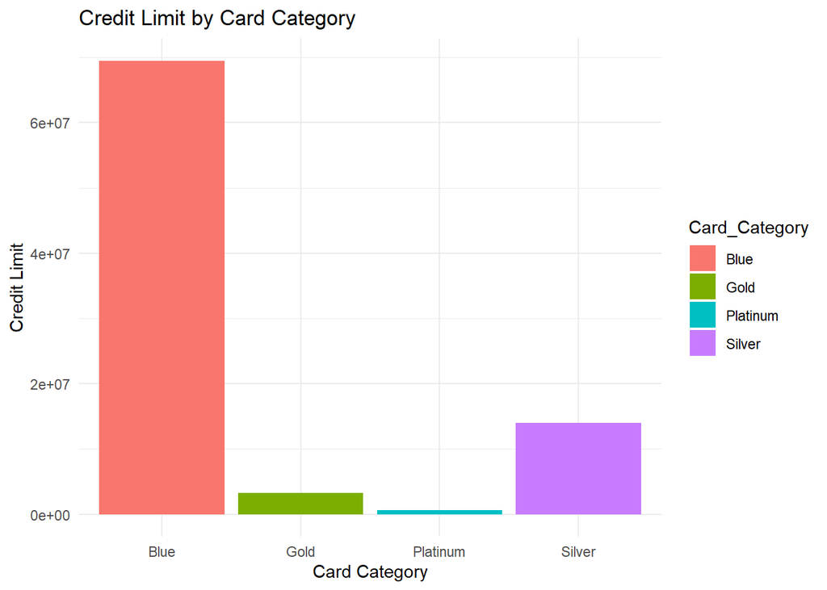

## EDA of Numerical Variables

The exploratory data analysis (EDA) conducted on the dataset focuses on its numerical variables, shedding light on key financial attributes of the customers. Among these variables, “Customer_Age,” “Total_Trans_Amt,” “Total_Trans_Ct,” and “Credit_Limit” are examined in detail. By employing histograms and density curves, the EDA reveals critical insights into the financial behaviors and characteristics of the customers.The “Customer_Age” histogram, using a bin width of 3, provides a comprehensive view of the age distribution within the customer base. This visualization helps identify whether the customer population is skewed towards a particular age group or exhibits distinct gaps or anomalies in age distribution. Such insights can guide targeted marketing and product development efforts.

Moving to transaction-related attributes, the histograms for “Total_Trans_Amt” and “Total_Trans_Ct” are essential for understanding customer spending patterns. With bin widths of 500 and 7, respectively, these visualizations unveil the distribution of total transaction amounts and counts. They are instrumental in pinpointing concentration ranges and detecting potential outliers within the transaction data. This knowledge can inform strategies for customer engagement, loyalty programs, and credit limit adjustments. Overall, the EDA of the numerical variables lays the groundwork for more advanced data analysis, empowering data scientists and business analysts to make data-driven decisions and tailor financial offerings to better serve the customer base.

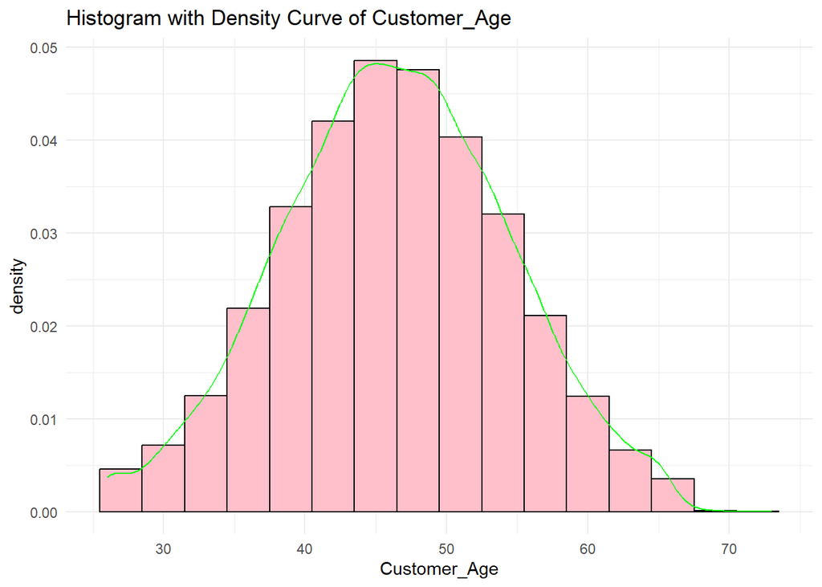

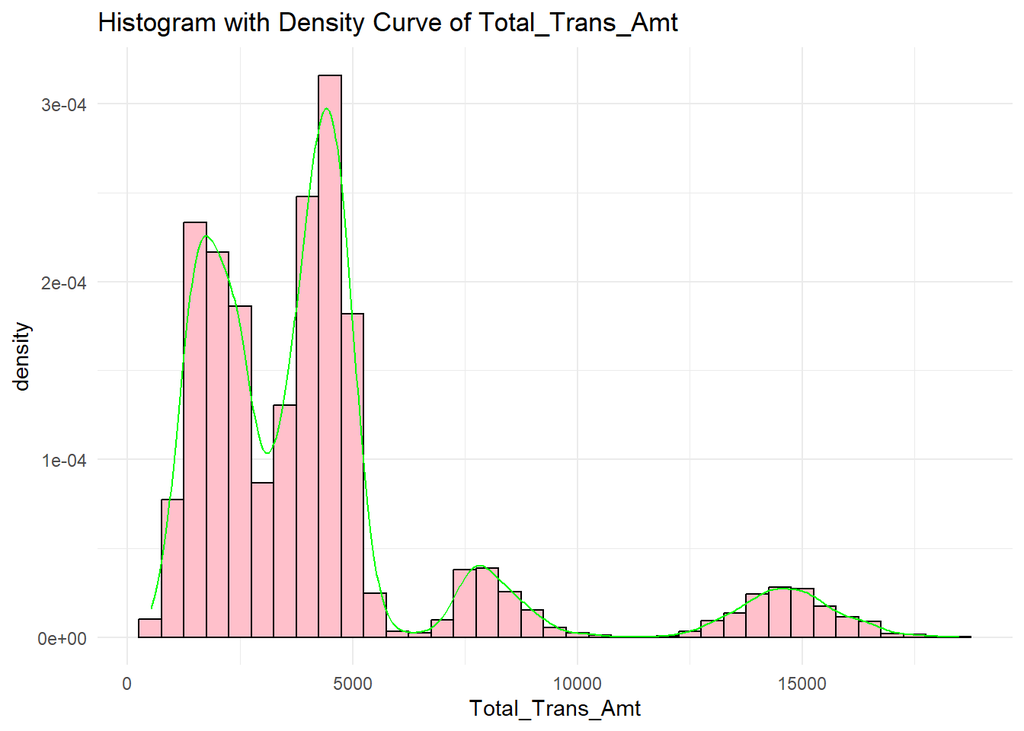

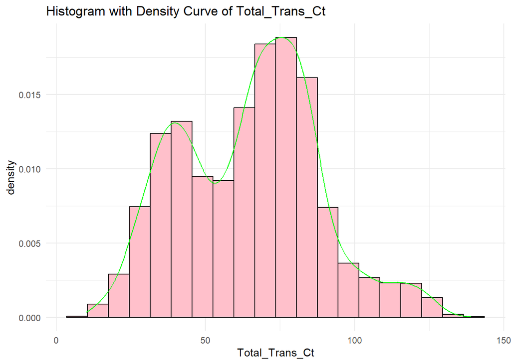

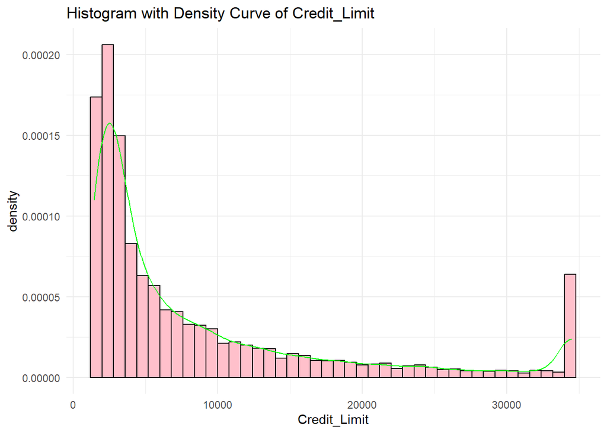

## Segmentation

#### A.Customer Segmentation

[figure not shown]

```
##   Average_Age Average_Income
## 1    46.32596             NA
```

#### B. Card Segmentation

The segmentation process also serves to enhance customer experience and loyalty. By acknowledging the varying preferences and financial capacities of customers in different card segments, institutions can customize their interactions and tailor their services to meet the unique demands of each group. This tailored approach not only attracts new customers but also strengthens relationships with existing ones, thereby fostering customer retention and overall business growth. As credit card companies continue to refine their segmentation strategies, they position themselves to remain competitive and relevant in the ever-evolving financial services industry.

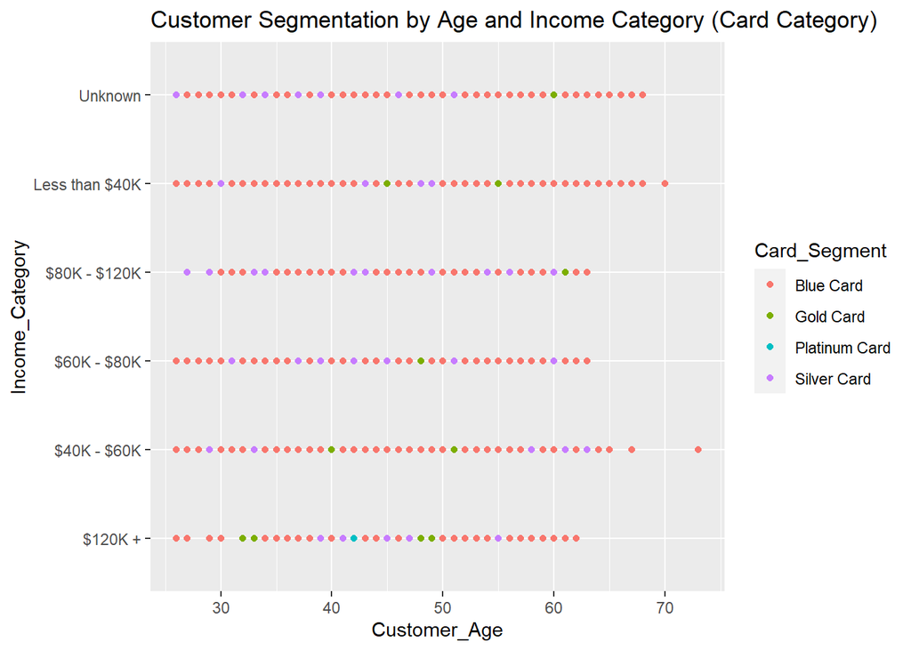

```
##   Average_Age Average_Income
## 1    46.32596             NA
```

## Correlation Analysis

The correlation analysis conducted provides essential insights into the relationships between numerical variables within the credit card dataset. This analysis is invaluable for understanding how various factors interplay and influence customer behavior and financial outcomes. By calculating the correlation matrix, we can identify which numerical attributes are positively or negatively correlated, shedding light on which variables tend to move in the same or opposite directions. This information aids in making informed decisions related to marketing strategies, risk assessment, and product development.

Moreover, the analysis takes the process a step further by setting a correlation threshold and systematically searching for highly correlated variable pairs. This step is particularly important for ensuring that our analytical models and strategies are robust and free from redundancy. Identifying and addressing highly correlated variable pairs prevents potential bias and inaccuracies in predictive modeling, thus enabling us to provide more tailored services and improve the overall customer experience. In essence, this correlation analysis is a fundamental tool for optimizing our decision-making processes and delivering enhanced financial services to our customers.

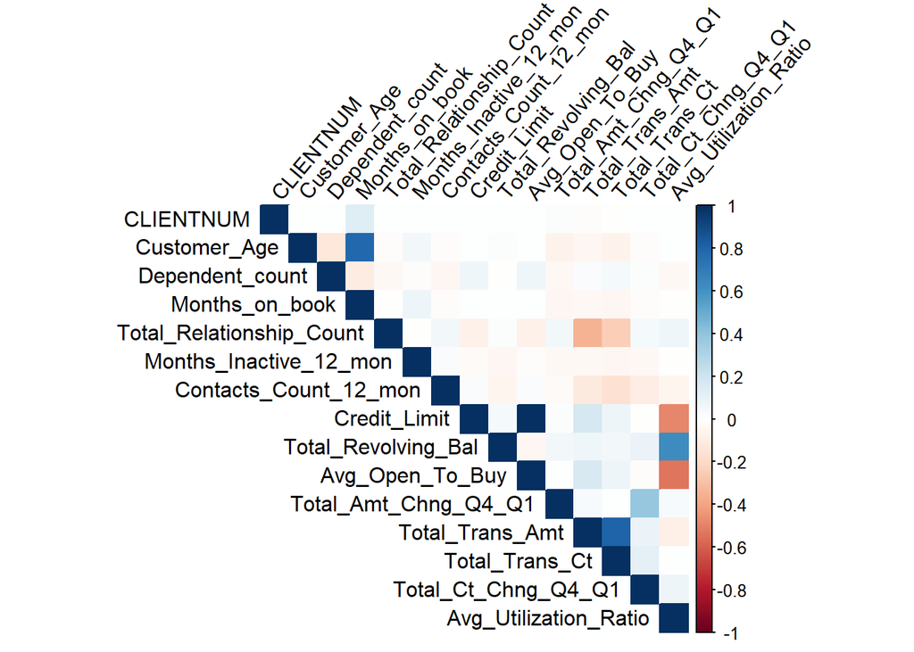

## Outlier Detection and removal

The outlier detection and removal process is a crucial step in data preprocessing to maintain the overall quality of the dataset. It contributes to the reliability and accuracy of any subsequent analyses or modeling efforts. In the context of credit card data, outliers can often indicate unusual or irregular transactions or customer profiles that could skew statistical summaries or predictive models. Addressing outliers in attributes such as “Customer_Age,” “Credit_Limit,” “Months_on_book,” “Total_Revolving_Bal,” “Total_Trans_Amt,” “Total_Trans_Ct,” “Avg_Open_To_Buy,” and “Avg_Utilization_Ratio” is especially important as these variables play a fundamental role in assessing customer creditworthiness and financial behavior. By replacing outlier values with missing data indicators (NA), we effectively mitigate their influence on the data, promoting more accurate and reliable insights for decision-makers in the financial industry.

Furthermore, the removal of outliers is essential for maintaining data consistency, improving the generalizability of machine learning models, and aligning financial products and services with the true financial profiles of customers. Outliers can skew the distribution of data, leading to misleading conclusions and hindering the ability to identify trends and patterns that are representative of the majority of customers. By systematically handling outliers, financial institutions can ensure that their analyses and models are more robust, and the decisions based on these insights are better suited to meet the diverse financial needs of their customer base, ultimately enhancing customer satisfaction and risk management strategies.

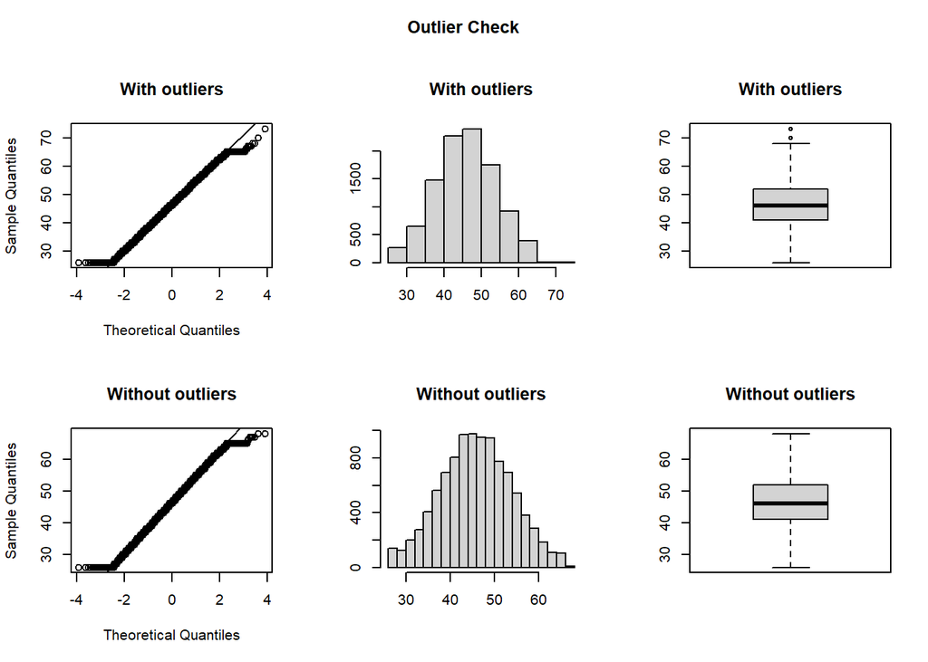

```
## Outliers identified: 2
## Proportion (%) of outliers: 0
## Mean of the outliers: 71.5
## Mean without removing outliers: 46.33
## Mean if we remove outliers: 46.32
## Outliers successfully removed
```

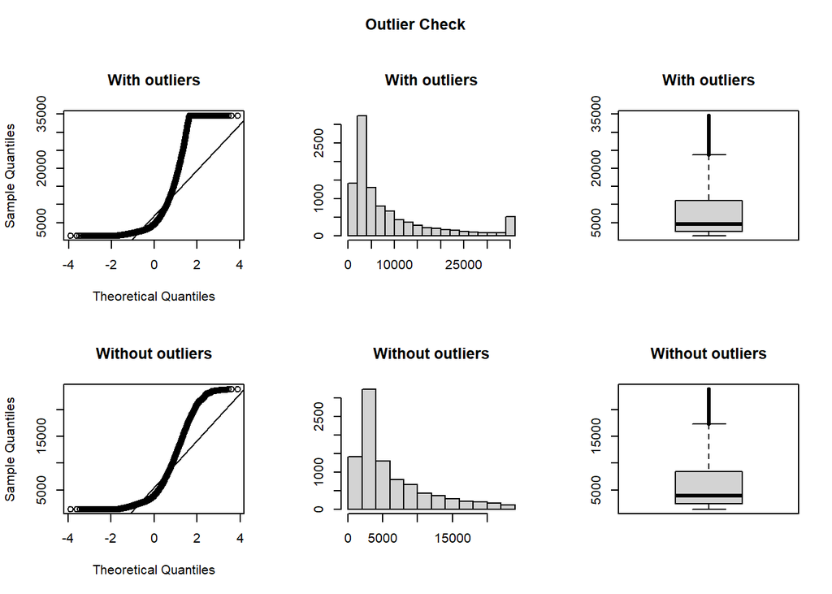

```
## Outliers identified: 984
## Proportion (%) of outliers: 10.8
## Mean of the outliers: 31551.34
## Mean without removing outliers: 8631.95
## Mean if we remove outliers: 6165.29
## Outliers successfully removed
```

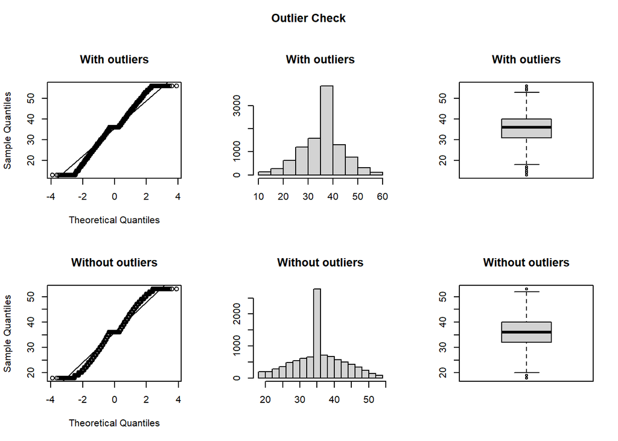

```
## Outliers identified: 386
## Proportion (%) of outliers: 4
## Mean of the outliers: 35.52
## Mean without removing outliers: 35.93
## Mean if we remove outliers: 35.94
## Outliers successfully removed
```

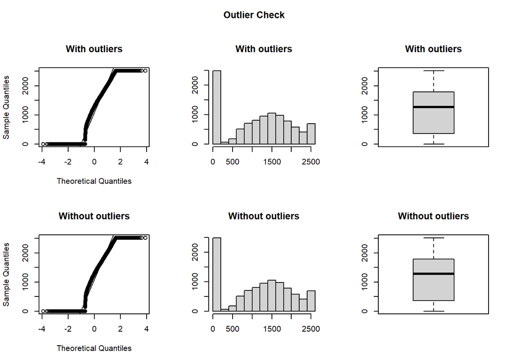

```
## Outliers identified: 0
## Proportion (%) of outliers: 0
## Mean of the outliers: NaN
## Mean without removing outliers: 1162.81
## Mean if we remove outliers: 1162.81
## Outliers successfully removed
```

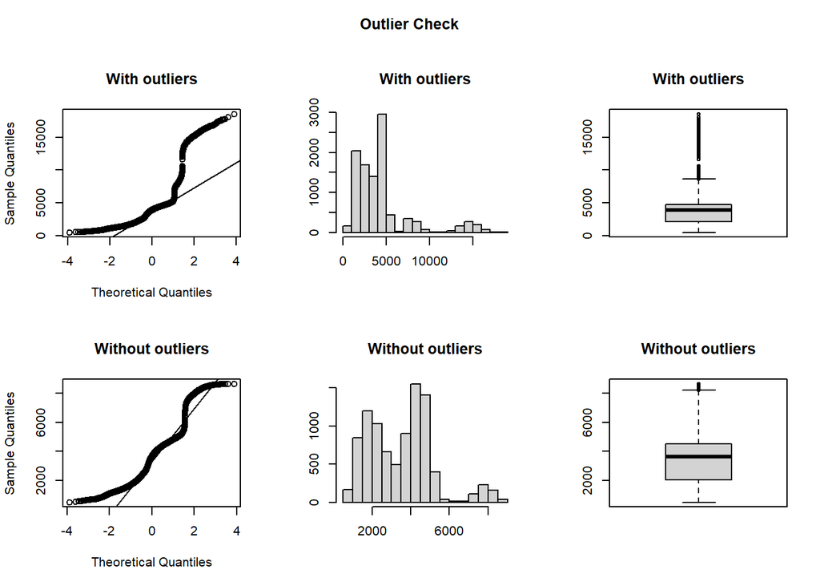

```
## Outliers identified: 896
## Proportion (%) of outliers: 9.7
## Mean of the outliers: 13770.19
## Mean without removing outliers: 4404.09
## Mean if we remove outliers: 3494.97
## Outliers successfully removed
```

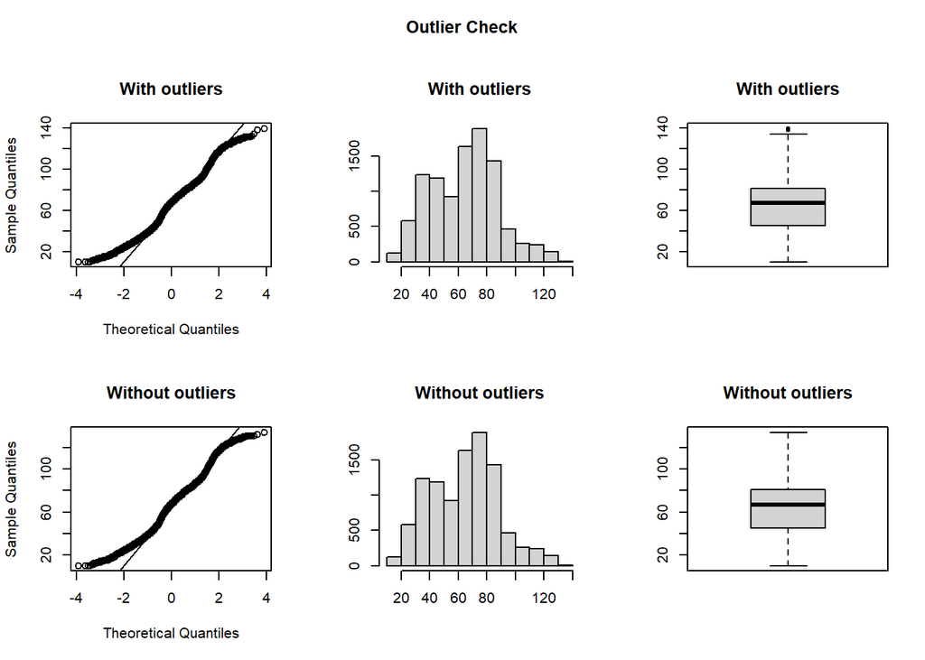

```
## Outliers identified: 2
## Proportion (%) of outliers: 0
## Mean of the outliers: 138.5
## Mean without removing outliers: 64.86
## Mean if we remove outliers: 64.84
## Outliers successfully removed
```

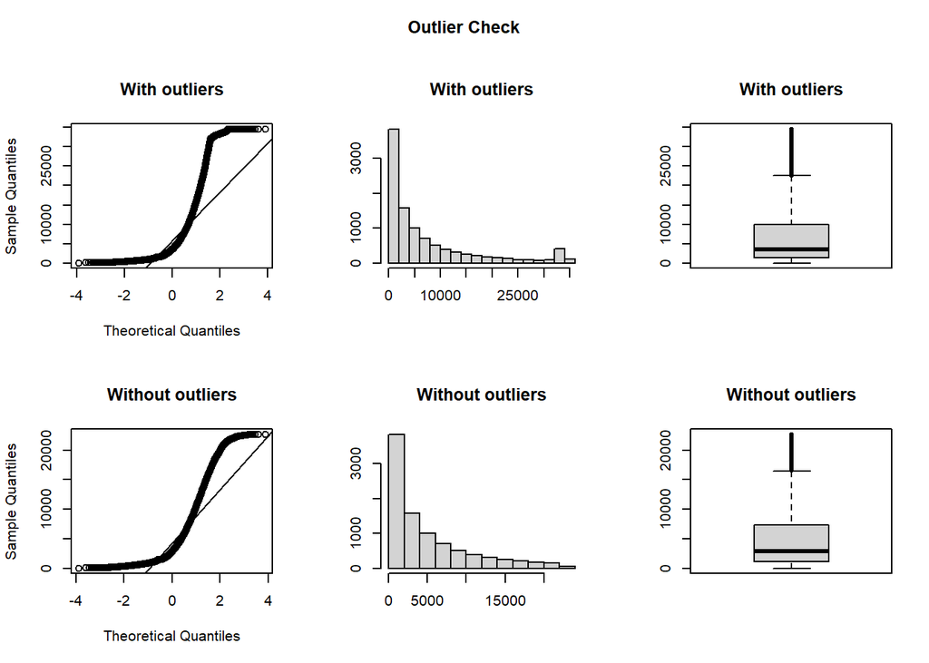

```
## Outliers identified: 963
## Proportion (%) of outliers: 10.5
## Mean of the outliers: 30531.66
## Mean without removing outliers: 7469.14
## Mean if we remove outliers: 5045.61
## Outliers successfully removed
```

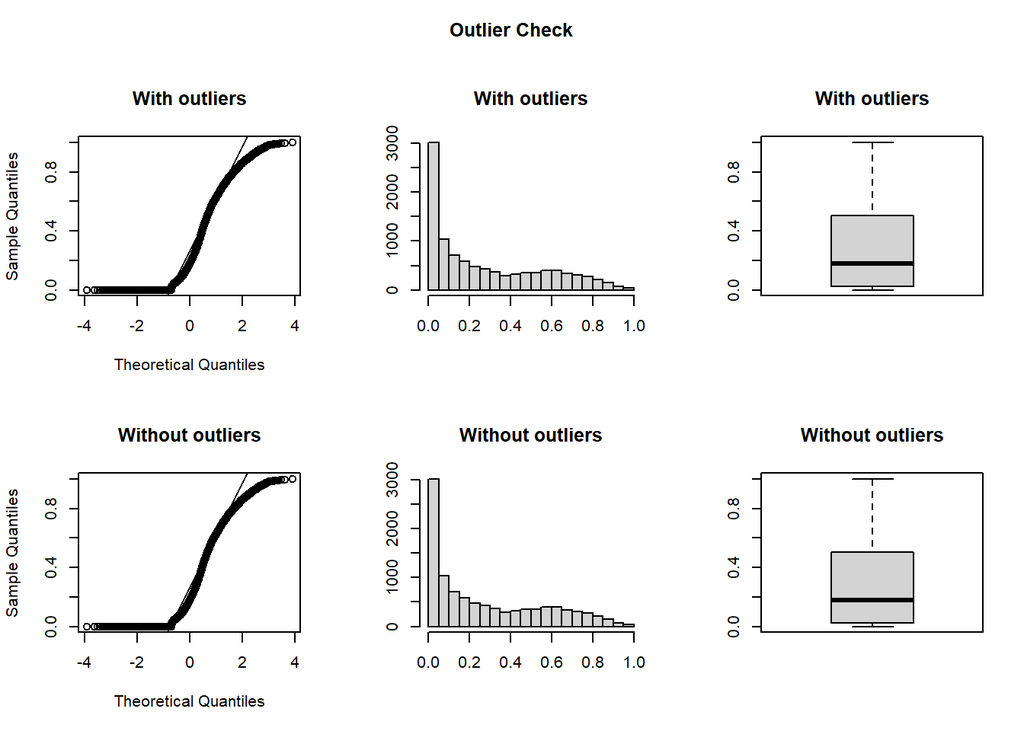

```
## Outliers identified: 0
## Proportion (%) of outliers: 0
## Mean of the outliers: NaN
## Mean without removing outliers: 0.27
## Mean if we remove outliers: 0.27
## Outliers successfully removed
```

## Standard Deviation

The computation of standard deviations for various attributes within the credit card dataset is a fundamental statistical analysis that provides insights into the data’s dispersion and variability. This measure of dispersion is particularly valuable in the financial industry as it aids in understanding the distribution of important attributes such as “Customer_Age,” “Credit_Limit,” “Months_on_book,” “Avg_Open_To_Buy,” “Avg_Utilization_Ratio,” “Total_Revolving_Bal,” “Total_Trans_Amt,” and “Total_Trans_Ct.” The standard deviation indicates the degree to which these variables deviate from their respective means. For instance, a higher standard deviation implies greater variability or spread in the data, while a lower standard deviation suggests more concentrated values around the mean. By calculating and summarizing the standard deviations for these attributes, financial analysts can gain valuable insights into the level of risk and variability associated with different aspects of customer credit profiles.

Moreover, the standard deviations can inform data-driven decision-making processes within the financial sector. They help in identifying attributes that exhibit significant variations, potentially indicating areas where financial institutions need to apply more focused risk management strategies or tailor their services accordingly. Additionally, standard deviations play a pivotal role in portfolio management and assessing the volatility of financial products. Understanding the spread of key variables like “Credit_Limit” or “Total_Trans_Amt” is essential for pricing models and assessing customer creditworthiness. By effectively interpreting and utilizing the standard deviations of these attributes, financial institutions can make informed decisions to enhance their risk assessment processes and better serve their customers.

```
##                  Column Standard_Deviation
## 1          Customer_Age          8.0168140
## 2          Credit_Limit       9088.7766502
## 3        Months_on_book          7.9864163
## 4       Avg_Open_To_Buy       9090.6853237
## 5 Avg_Utilization_Ratio          0.2756915
## 6   Total_Revolving_Bal        814.9873352
## 7       Total_Trans_Amt       3397.1292536
## 8        Total_Trans_Ct         23.4725704
```

## Analyzing Gender Differences in Total Transaction Amount

In this analysis, we aim to investigate potential differences in the total transaction amount based on gender among credit card holders. A two-sample t-test is performed to compare the means of total transaction amounts for male and female cardholders. The results of the t-test will determine whether there is a statistically significant difference in transaction amounts between these two gender groups.

The outcome of this analysis provides insights into whether gender plays a significant role in influencing the total transaction amounts for credit card holders. Financial institutions can utilize this information to tailor their marketing strategies, develop gender-specific offers, or address any gender-based variations in transaction behavior. By understanding the gender-specific patterns in total transaction amounts, credit card providers can enhance their customer engagement and satisfaction strategies to better serve the diverse needs of their clientele.

```
## [1] "T-test for Total_Trans_Amt and Gender"
```

```
##
##  Welch Two Sample t-test
##
## data:  credit_card_no_outliers$Total_Trans_Amt by credit_card_no_outliers$Gender
## t = -2.4682, df = 8913.9, p-value = 0.0136
## alternative hypothesis: true difference in means between group F and group M is not equal to 0
## 95 percent confidence interval:
##  -303.91381  -34.86222
## sample estimates:
## mean in group F mean in group M
##        4324.318        4493.706
```

## Analyzing Income Category for Credit Card Churn

```
##
##  One Sample t-test
##
## data:  table_data
## t = 2.2834, df = 35, p-value = 0.02859
## alternative hypothesis: true mean is not equal to 0
## 95 percent confidence interval:
##   31.20699 531.40412
## sample estimates:
## mean of x
##  281.3056
```

## Data Visualization for Credit Card Analysis

The data visualizations offer valuable insights into the credit card dataset. The first plot illustrates the relationship between “Credit Limit” and “Average Utilization Ratio.” It employs a scatter plot to display individual data points, enabling a quick overview of the connection between credit limits and utilization ratios.

The second plot focuses on understanding the relationship between “Age” and “Credit Limit” while distinguishing income categories by color. By color-coding different income categories, this plot facilitates a deeper analysis, helping identify age-related patterns in credit limits based on income categories. These visualizations are instrumental in making complex data more accessible and guiding further exploration and analysis of the dataset.

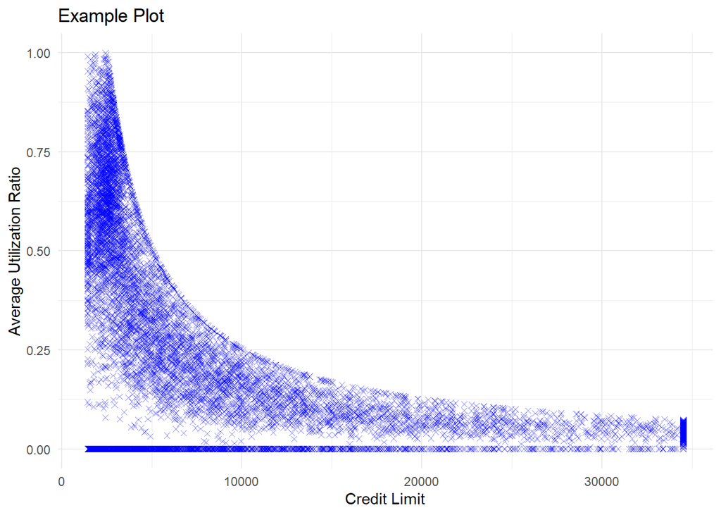

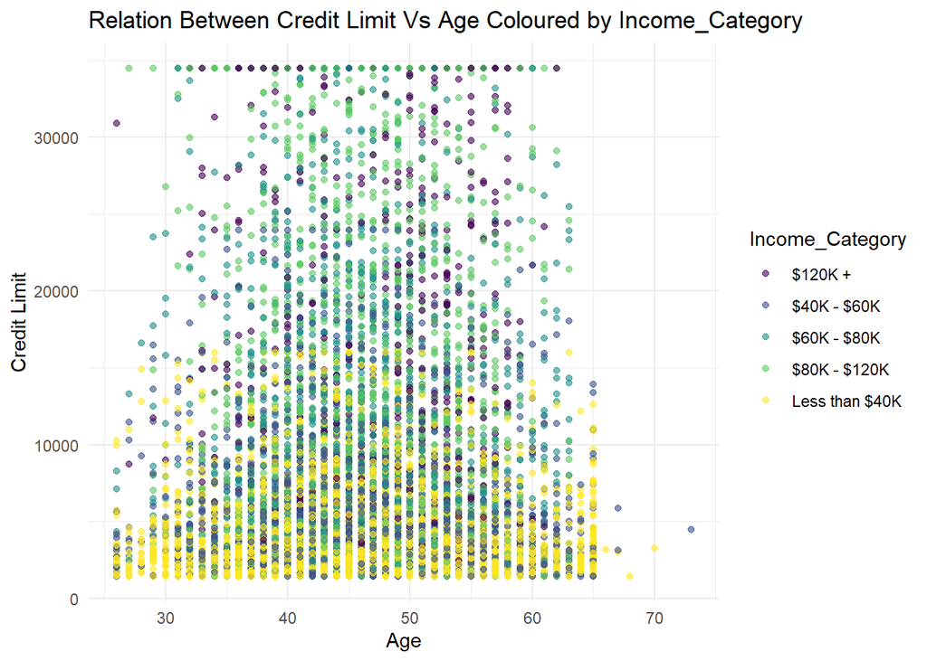

## Analysis of Contacts Count and Customer Attrition

This analysis involves conducting an independent samples t-test to examine the differences in the number of contacts made in the last 12 months (Contacts_Count_12_mon) between two groups: attrited customers and existing customers. The t-test is utilized to determine whether there is a statistically significant difference in the mean number of contacts between these groups. The results of the t-test provide valuable insights into whether the frequency of contacts made with customers is related to their attrition status. By understanding such relationships, financial institutions can optimize their customer engagement strategies and adjust contact frequencies to improve customer retention rates and overall satisfaction.

```
##
##  Welch Two Sample t-test
##
## data:  attrition_group and non_attrition_group
## t = 20.901, df = 2280.3, p-value < 2.2e-16
## alternative hypothesis: true difference in means is not equal to 0
## 95 percent confidence interval:
##  0.5581957 0.6737818
## sample estimates:
## mean of x mean of y
##  2.972342  2.356353
```

## Income Category and Attrition Analysis

This analysis involves investigating the relationship between income categories and customer attrition within the credit card customer base. A contingency table is constructed to examine the distribution of customers across different income categories (ranging from less than $40K to greater than $120K) concerning their attrition status. Additionally, a chi-squared test is conducted to determine whether there is a statistically significant association between income category and attrition. The outcome of this analysis helps identify whether certain income categories are more prone to customer attrition than others. Furthermore, the attrition rate for each income category is calculated to provide insights into the proportion of customers who have attrited in relation to the total number of customers in that income bracket. This information is valuable for financial institutions to tailor retention strategies and services to specific income categories, ultimately reducing customer attrition rates.

```
##
##                  Attrited Customer Existing Customer
##   $120K +                      126               601
##   $40K - $60K                  271              1519
##   $60K - $80K                  189              1213
##   $80K - $120K                 242              1293
##   Less than $40K               612              2949
##   Unknown                      187               925
```

```
##
##  Pearson's Chi-squared test
##
## data:  contingency_table_income
## X-squared = 12.832, df = 5, p-value = 0.025
```

```
##        $120K +    $40K - $60K    $60K - $80K   $80K - $120K Less than $40K
##       17.33150       15.13966       13.48074       15.76547       17.18618
##        Unknown
##       16.81655
```

## Gender-Based Comparison of Average Utilization Ratio

This statistical analysis explores gender-based differences in the average utilization ratio among credit card customers. By segregating the dataset into male and female customers and calculating the t-test, we gain insights into whether there are significant variations in how individuals of different genders utilize their credit limits. The results of the t-test provide valuable information regarding whether there is a statistically significant difference between the average utilization ratios of male and female customers. Understanding such differences can be instrumental in tailoring credit card offerings and services to cater to the specific financial behaviors and preferences of various gender groups.

```
##
##  Welch Two Sample t-test
##
## data:  male_utilization and female_utilization
## t = 27.213, df = 9993.8, p-value < 2.2e-16
## alternative hypothesis: true difference in means is not equal to 0
## 95 percent confidence interval:
##  0.1321507 0.1526665
## sample estimates:
## mean of x mean of y
## 0.3419565 0.1995479
```

## Conclusion

We also delved into numerical variables like age, credit limits, transaction behavior, and more. Exploratory data analysis, outlier detection, and correlation analysis helped uncover relationships and trends within the dataset. For instance, we identified high correlations between attributes like total revolving balance and average utilization ratio, providing actionable insights for customer engagement and targeted offers. The standard deviation analysis offered a more in-depth understanding of the dataset’s numerical variability, facilitating better-informed decision-making. In conclusion, this data-driven analysis has equipped financial institutions with valuable information to refine their marketing, product development, and customer retention strategies. By understanding customer behavior, preferences, and segmentation, credit card providers can enhance customer satisfaction, reduce attrition rates, and foster stronger relationships with their clientele. This study underscores the importance of data-driven decision-making in the ever-evolving landscape of the financial services industry.

## References

1. Muneer, A., Ali, R. F., Alghamdi, A., Taib, S. M., Almaghthawi, A., & Ghaleb, E. A. (2022). Predicting customers churning in banking industry: A machine learning approach. Indones. J. Electr. Eng. Comput. Sci, 26(1), 539-549. https://www.academia.edu/download/92955405/58_27450_v26i1_Apr22.pdf
2. Lalwani, P., Mishra, M. K., Chadha, J. S., & Sethi, P. (2022). Customer churn prediction system: a machine learning approach. Computing, 1-24. https://link.springer.com/article/10.1007/s00607-021-00908-y
3. Nadim, A. H., Sayem, I. M., Mutsuddy, A., & Chowdhury, M. S. (2019, December). Analysis of machine learning techniques for credit card fraud detection. In 2019 International Conference on Machine Learning and Data Engineering (iCMLDE) (pp. 42-47). IEEE. https://ieeexplore.ieee.org/document/8995753
4. SriLaxmi, K., Sri, N. D., Bhavani, P. L. D., Rani, A. V., Fatima, S. H., & Tanuj, A. Credit Card Customer Predicting using Machine Learning. https://www.academia.edu/download/63648093/45220200616-92158-d5wdnr.pdf
5. Kumar, R. R., Sahithi, B., Neeharika, K., Shivaleela, M., Singh, D., & Reddy, K. R. K. (2023). Automation of Credit Card Customer Churn Analysis using Hybrid Machine Learning Models. In E3S Web of Conferences (Vol. 430, p. 01034). EDP Sciences. https://www.e3s-conferences.org/articles/e3sconf/pdf/2023/67/e3sconf_icmpc2023_01034.pdf